# p8105_hw1_yz4717

Yang Zhao__yz4717

2023-09-18

First of all, I input the data which was mentioned in the problem and all the needed packages.

```r
library(moderndive)# data
library(tidyverse)# pull
library(ggplot2) # ggplot
data("early_january_weather")
```

## Problem 1

As mentioned, we can use the function “names()” to list all the variables.

```r
names(early_january_weather)#list names
```

```
##  [1] "origin"     "year"       "month"      "day"        "hour"
##  [6] "temp"       "dewp"       "humid"      "wind_dir"   "wind_speed"
## [11] "wind_gust"  "precip"     "pressure"   "visib"      "time_hour"
```

All names of vectors are shown above.

```r
skimr::skim(early_january_weather)#summary
```

Data summary

| Name | early_january_weather |
| --- | --- |
| Number of rows | 358 |
| Number of columns | 15 |
| _______________________ |  |
| Column type frequency: |  |
| character | 1 |
| numeric | 13 |
| POSIXct | 1 |
| ________________________ |  |
| Group variables | None |

**Variable type: character**

| skim_variable | n_missing | complete_rate | min | max | empty | n_unique | whitespace |
| --- | --- | --- | --- | --- | --- | --- | --- |
| origin | 0 | 1 | 3 | 3 | 0 | 1 | 0 |

**Variable type: numeric**

| skim_variable | n_missing | complete_rate | mean | sd | p0 | p25 | p50 | p75 | p100 | hist |
| --- | --- | --- | --- | --- | --- | --- | --- | --- | --- | --- |
| year | 0 | 1.00 | 2013.00 | 0.00 | 2013.00 | 2013.00 | 2013.00 | 2013.00 | 2013.00 | ▁▁▇▁▁ |
| month | 0 | 1.00 | 1.00 | 0.00 | 1.00 | 1.00 | 1.00 | 1.00 | 1.00 | ▁▁▇▁▁ |
| day | 0 | 1.00 | 8.04 | 4.31 | 1.00 | 4.00 | 8.00 | 12.00 | 15.00 | ▇▇▇▇▇ |
| hour | 0 | 1.00 | 11.53 | 6.92 | 0.00 | 6.00 | 11.50 | 17.75 | 23.00 | ▇▇▆▇▇ |
| temp | 0 | 1.00 | 39.58 | 7.06 | 24.08 | 33.98 | 39.02 | 44.96 | 57.92 | ▃▇▇▇▁ |
| dewp | 0 | 1.00 | 28.06 | 10.73 | 8.96 | 19.94 | 26.06 | 35.06 | 53.06 | ▃▇▆▂▃ |
| humid | 0 | 1.00 | 65.48 | 18.95 | 32.86 | 51.34 | 61.67 | 78.68 | 100.00 | ▃▇▆▂▅ |
| wind_dir | 5 | 0.99 | 208.19 | 115.58 | 0.00 | 140.00 | 240.00 | 290.00 | 360.00 | ▅▁▂▇▆ |
| wind_speed | 0 | 1.00 | 8.23 | 4.61 | 0.00 | 5.75 | 8.06 | 11.51 | 24.17 | ▅▇▆▂▁ |
| wind_gust | 308 | 0.14 | 22.53 | 3.63 | 16.11 | 19.56 | 21.86 | 25.32 | 31.07 | ▅▇▃▇▁ |
| precip | 0 | 1.00 | 0.00 | 0.01 | 0.00 | 0.00 | 0.00 | 0.00 | 0.19 | ▇▁▁▁▁ |
| pressure | 38 | 0.89 | 1022.52 | 5.57 | 1010.80 | 1018.30 | 1022.05 | 1027.23 | 1034.40 | ▃▇▇▇▃ |
| visib | 0 | 1.00 | 8.52 | 3.00 | 0.12 | 9.00 | 10.00 | 10.00 | 10.00 | ▁▁▁▁▇ |

**Variable type: POSIXct**

| skim_variable | n_missing | complete_rate | min | max | median | n_unique |
| --- | --- | --- | --- | --- | --- | --- |
| time_hour | 0 | 1 | 2013-01-01 01:00:00 | 2013-01-15 23:00:00 | 2013-01-08 12:30:00 | 358 |

There are numerous parameters in the summary, I prefer to talk about two special parameters.First, the completion of gust speed is in poor condition, which only accounts for 14%. In such circumstance, this variable is unable to use. When it comes to wind direction, its variance is the highest among these variables. In other words, its has a wide range.

```r
shape_row = nrow(early_january_weather)#get rows
shape_col = ncol(early_january_weather)#get cols
```

The dataset contains 358 Rows * 15 Columns.

```r
rs_mean = mean(early_january_weather$temp)# calculate mean
```

The temperature’s mean is shown above, and the result is 39.5821229 Fahrenheit degree. Then, I used the ggplot function to generate a scatterplot of temperature and time.The specific procedure will be shown in the following chunck.

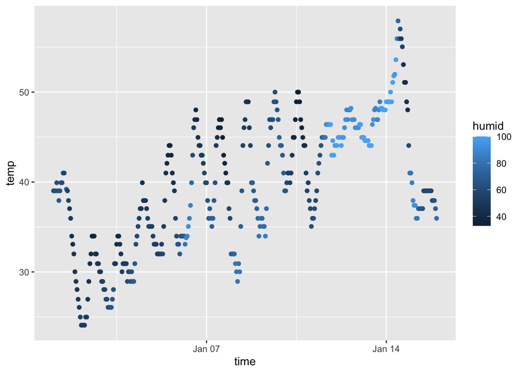

```r
time_temp_tib = tibble(
  time = pull(early_january_weather,time_hour),
  temp = pull(early_january_weather,temp),
  humid = pull(early_january_weather,humid)
)# get vector from dataframe

plot_sc =
  ggplot(
  data = time_temp_tib, aes(
    x = time,
    y = temp,
    color = humid)
)+geom_point()
#if we want to draw a curve a line, we can use geom_aline()

plot_sc # display plot
```

```r
ggsave("sc_plot.png",device = "png") #save it to default file
```

Then, I use “ggsave” to save last plot.

## Problem 2

In problem 2, I generated 4 different vector and grouped them into a data frame. The specific code and result are shown in following chunk. To group all the variables in a data frame without warnings, length of variables should be 10. A numeric vector will be generated from normal distribution with mean = 0 and variance = 1. Then, logic variables will determine if numeric variable is greater than 0.

```r
vc_norm = rnorm(10,mean = 0,sd = 1)

vc_logic = vc_norm > 0

vc_char = c("a","b","c","d","e","f","g","h","i","j")

vc_fac = factor(
  c("Low", "Medium", "Low", "High", "Medium",
    "Low", "High","Medium", "Low", "High"))

#generate 4 different vectors

combined_frame = data.frame(
  normal_distri = vc_norm,
  logical_vc = vc_logic,
  character_vc = vc_char,
  factor_vc = vc_fac
)

#group them into a dataframe
```

Then, I tried to calculate average of these four vector.

```r
mean_1 = mean(vc_norm)
mean_2 = mean(vc_logic)
mean_3 = mean(vc_char)
```

```
## Warning in mean.default(vc_char): argument is not numeric or logical: returning
## NA
```

```r
mean_4 = mean(vc_fac)
mean_rs = list(mean_1,mean_2,mean_3,mean_4)
mean_rs
```

```
## [[1]]
## [1] -0.1774958
##
## [[2]]
## [1] 0.4
##
## [[3]]
## [1] NA
##
## [[4]]
## [1] NA
```

As the question mentioned, I used “mean()” function to calculate average. As you can see, this function can calculate the mean of numeric and logical vector. From our actual perceptions，it is obvious that it can calculate numeric vector and can not calculate character vector.This reason is also true for the factor variable, which is essentially still a character variable at this point. When it comes to logical vector, the reason we can still get results is that logical value is a simple ‘0’ or ‘1’ in computer system(which stands for ‘False’ or ‘True’ respectively).

```r
vc_norm_new = as.numeric(vc_norm)

vc_logic_new = as.numeric(vc_logic)

vc_char_new = as.numeric(vc_char)

vc_fac_new = as.numeric(vc_fac)


cframe_new = list(
  vc_norm_new,
  vc_logic_new,
  vc_char_new,
  vc_fac_new
)
```

As the former analysis mentioned, logical and numeric vector can convert into numeric one without any difficulty just because they are actual numbers in the system. for the same reason, the system can’t convert character vector. When it comes to factor vector, if we force R to do a type conversion, the system will convert them into real numbers automatically.

```r
mean_rs_new = list(
  mean(vc_norm_new),
  mean(vc_logic_new),
  mean(vc_char_new),
  mean(vc_fac_new)
)
```